# Nanofish: ROS levels

# Set up environment

## Load libraries

## Load functions

## Load data

### Adjust classes and transformations

```
'data.frame':   467 obs. of  30 variables:
 $ StudyID             : Factor w/ 59 levels "2","3","4","5",..: 40 40 50 50 50 50 16 16 16 7 ...
 $ StudyCluster        : Factor w/ 34 levels "1","2","3","5",..: 4 4 5 5 5 5 4 4 4 18 ...
 $ Study               : Factor w/ 59 levels "Ašmonaitė et al., 2020",..: 1 1 2 2 2 2 3 3 3 4 ...
 $ Year                : int  2020 2020 2018 2018 2018 2018 2020 2020 2020 2019 ...
 $ EScluster           : Factor w/ 101 levels "1","2","3","4",..: 1 1 2 2 2 2 3 3 3 4 ...
 $ AdministrationRoute : Factor w/ 6 levels "Food","Injection",..: 1 1 4 4 4 4 1 1 1 4 ...
 $ Concentration_mg_L  : num  NA NA 0.26 0.69 0.26 0.69 NA NA NA 20 ...
 $ ParticleMaterial    : Factor w/ 7 levels "Aminoplast","LDPE",..: 6 3 1 1 1 1 3 3 3 6 ...
 $ Species             : Factor w/ 20 levels "Argyrosomus regius",..: 9 9 8 8 8 8 9 9 9 7 ...
 $ ParticleShape       : Factor w/ 4 levels "Irregular","Sphere",..: 2 2 2 2 2 2 2 2 2 2 ...
 $ Sex                 : Factor w/ 5 levels "F","F:M","FM",..: 5 5 5 5 5 5 5 5 5 NA ...
 $ DevelopmentalStage  : Factor w/ 5 levels "Embrio","Larva",..: 4 4 4 4 4 4 4 4 4 2 ...
 $ ExposureDurationCat : Factor w/ 3 levels "15 days +","5-15 days",..: 2 2 3 3 3 3 1 1 1 3 ...
 $ ExposureDurationDays: int  14 14 4 4 4 4 28 28 28 2 ...
```

[output cut: 16 more lines]

### Calculate Effect Size

```r
df_original <- metafor::escalc(measure = "SMD", n1i = n_treat, n2i = n_ctrl, m1i = mean_treat,
    m2i = mean_ctrl, sd1i = STD_treat, sd2i = STD_ctrl, data = df_original, vtype = "UB")
# write.csv(df_original,file = 'mvMetaAnalysis_SMDs.csv')
```

### Create variables

```r
outcome <- as.character(outcomeslist[[n_outcome]])

mRF <- list()  # random effects formula investigation models
mRE <- list()  # random effects multilevel models
mMR <- list()  # multilevel metaregression models

colormap <- c(Embrio = "khaki", Larva = "lightgreen", Juvenile = "lightskyblue",
    Adult = "salmon", Unclear = "plum", ExposureDurationDays = "cornflowerblue",
    ParticleSizeMean = "chartreuse4", Concentration_mg_L = "#fa0079ff", Aminoplast = "chocolate4",
    LDPE = "#2200faff", PE = "#0089faff", PET = "#00faedff", PLA = "#00fa29ff", PS = "#faf200ff",
    PVC = "#fa9a00ff", `Publication year` = "black", Variance = "navyblue")
```

### Select outcome

```
[1] "ROS levels"
```

|  | StudyID | StudyCluster | Study | Year | EScluster | AdministrationRoute | Concentration_mg_L | ParticleMaterial | Species | ParticleShape | Sex | DevelopmentalStage | ExposureDurationCat | ExposureDurationDays | ParticleSizeRange | ParticleSizeMean | ParticleSizeCat | Outcome | OutcomeCategory | Test_or_Assay | OutcomeVariable | Group | n_of_groups | n_ctrl | mean_ctrl | STD_ctrl | n_treat | mean_treat | STD_treat | … |
| --- | --- | --- | --- | --- | --- | --- | --- | --- | --- | --- | --- | --- | --- | --- | --- | --- | --- | --- | --- | --- | --- | --- | --- | --- | --- | --- | --- | --- | --- | --- |
| 35 | 28 | 1 | Chagas et al., 2021 | 2021 | 9 | Water: Semi-static system | 2.5 | PLA | Danio rerio | Irregular | FM | Adult | 15 days + | 30 | 2.34 | 2.34 | micro | ROS levels | Neurochemical outcomes | Oxidative Stress | ROS levels | BP I (2,5 mg/L) | 2 | 10 | 11.406 | 0.282 | 10 | 14.095 | 0.982 | … |
| 36 | 28 | 1 | Chagas et al., 2021 | 2021 | 9 | Water: Semi-static system | 5 | PLA | Danio rerio | Irregular | FM | Adult | 15 days + | 30 | 2.34 | 2.34 | micro | ROS levels | Neurochemical outcomes | Oxidative Stress | ROS levels | BP II (5 mg/L) | 2 | 10 | 11.406 | 0.282 | 10 | 14.351 | 0.753 | … |
| 102 | 59 | 1 | Estrela et al., 2021 | 2021 | 38 | Water: Static system | 0.76 | PS | Ctenopharyngodon idella | Sphere | F:M | Juvenile | up to 96h | 3 | 0.02-0.026 | 0.023 | nano | ROS levels | Neurochemical outcomes | Oxidative Stress | ROS levels | PS NP | 1 | 16 | 1184.23 | 283.548 | 16 | 736.922 | 30.326 | … |
| 149 | 2 | 33 | Ji et al., 2020 | 2020 | 48 | Water: Unclear | 10 | PET | Danio rerio | Irregular |  | Larva | 5-15 days | 5 | 0.02 | 0.02 | nano | ROS levels | Neurochemical outcomes | Oxidative Stress | ROS levels | PET@BSA20 | 3 | 45 | 125.023 | 19.798 | 45 | 285.9761687 | 79.56003667 | … |
| 150 | 2 | 33 | Ji et al., 2020 | 2020 | 48 | Water: Unclear | 10 | PET | Danio rerio | Irregular |  | Larva | 5-15 days | 5 | 0.08 | 0.08 | nano | ROS levels | Neurochemical outcomes | Oxidative Stress | ROS levels | PET@BSA80 | 3 | 45 | 125.023 | 19.798 | 45 | 248.9459212 | 50.59578369 | … |
| 151 | 2 | 33 | Ji et al., 2020 | 2020 | 48 | Water: Unclear | 10 | PET | Danio rerio | Irregular |  | Larva | 5-15 days | 5 | 0.8 | 0.8 | nano | ROS levels | Neurochemical outcomes | Oxidative Stress | ROS levels | PET@BSA800 | 3 | 45 | 125.023 | 19.798 | 45 | 138.2218149 | 42.8964253 | … |
| 152 | 2 | 33 | Ji et al., 2020 | 2020 | 49 | Water: Unclear | 10 | PET | Danio rerio | Irregular |  | Larva | 5-15 days | 5 | 0.02 | 0.02 | nano | ROS levels | Neurochemical outcomes | Oxidative Stress | ROS levels | PET@SDS20 | 3 | 45 | 131.622 | 38.863 | 45 | 199.8166819 | 56.82859762 | … |
| 153 | 2 | 33 | Ji et al., 2020 | 2020 | 49 | Water: Unclear | 10 | PET | Danio rerio | Irregular |  | Larva | 5-15 days | 5 | 0.06 | 0.06 | nano | ROS levels | Neurochemical outcomes | Oxidative Stress | ROS levels | PET@SDS60 | 3 | 45 | 131.622 | 38.863 | 45 | 184.4179652 | 32.99725023 | … |
| 154 | 2 | 33 | Ji et al., 2020 | 2020 | 49 | Water: Unclear | 10 | PET | Danio rerio | Irregular |  | Larva | 5-15 days | 5 | 0.8 | 0.8 | nano | ROS levels | Neurochemical outcomes | Oxidative Stress | ROS levels | PET@SDS800 | 3 | 45 | 131.622 | 38.863 | 45 | 224.0146654 | 60.49495876 | … |
| 156 | 4 | 18 | Lee et al., 2019 | 2019 | 51 | Water: Static system | 100 | PS | Danio rerio | Sphere |  | Embrio | up to 96h | 1 | 50 | 50 | nano | ROS levels | Neurochemical outcomes | Oxidative Stress | ROS levels | PS50 | 1 | 5 | 1.006 | 0.044 | 5 | 1.443 | 0.216 | … |

[output cut: 49 more lines]

# Exploratory data analysis

## Funnel plot

> Before running any meta-analytic model, it is important to explore the meta-analytic dataset to search for potential outliers that could represent data extraction errors. (Nakagawa et al. 2022)

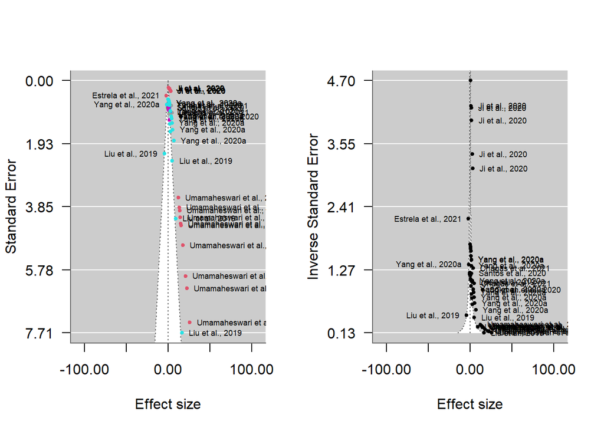

## Alluvial plot

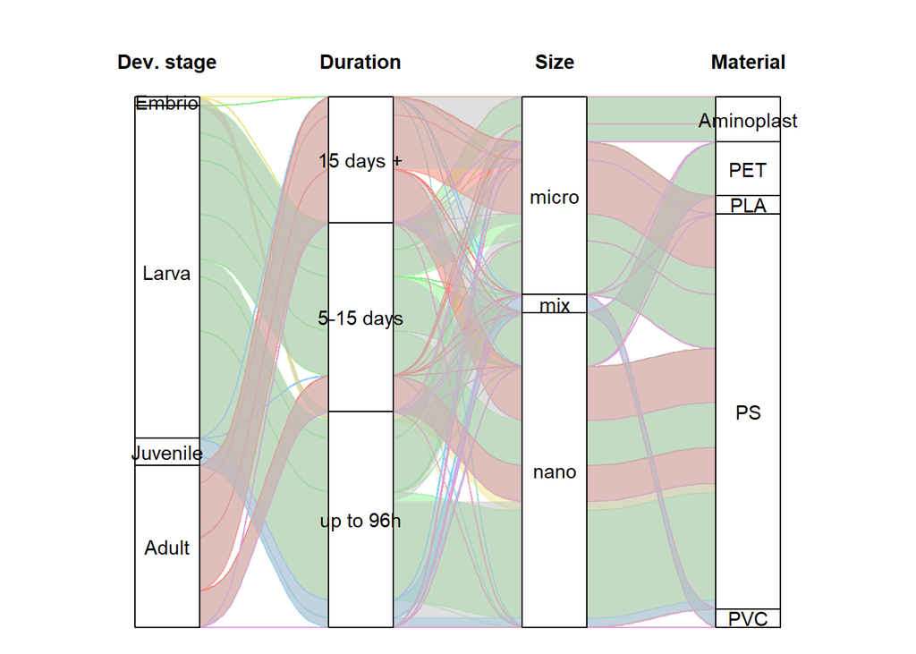

# Multilevel meta-analytic model

## Random effects formula desing

```
[1] "Considering number of studies: 13, number of ES clusters: 24 and number of independent observations of ES: 59, the random effects formula for ROS levels is: ~1 | Study/EScluster/ESid"
```

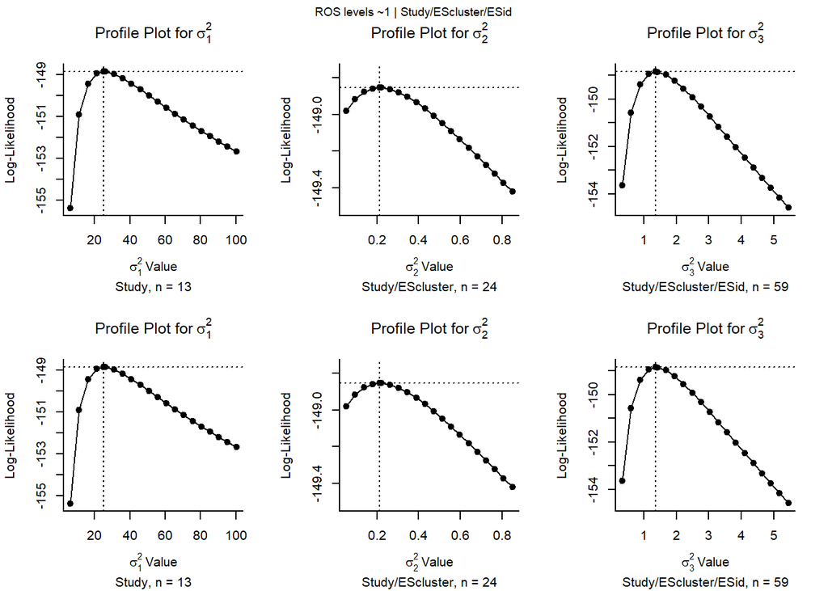

> A profile likelihood plot should show a single peak at the corresponding ML/REML estimate. If `refline=TRUE` (the default), the value of the parameter estimate is indicated by a dotted vertical line and its log-likelihood value by a dotted horizontal line. Hence, the intersection of these two lines should correspond to the peak (assuming that the model was fitted with ML/REML estimation).

> When profiling a variance component (or some other parameter that cannot be negative), the peak may be at zero (if this corresponds to the ML/REML estimate of the parameter). In this case, the profiled log-likelihood should be a monotonically decreasing function of the parameter. Similarly, when profiling a correlation component, the peak may be at -1 or +1.

> If the profiled log-likelihood has multiple peaks, this indicates that the likelihood surface is not unimodal. In such cases, the ML/REML estimate may correspond to a local optimum (when the intersection of the two dotted lines is not at the highest peak).

> If the profile is flat (over the entire parameter space or large portions of it), then this suggests that at least some of the parameters of the model are not identifiable (and the parameter estimates obtained are to some extent arbitrary). See Raue et al. (2009) for some further discussion of parameter identifiability and the use of profile likelihoods to check for this.

> The function checks whether any profiled log-likelihood value is actually larger than the log-likelihood of the fitted model (using a numerical tolerance of `lltol`). If so, a warning is issued as this might indicate that the optimizer did not identify the actual ML/REML estimate of the parameter profiled.[Viechtbauer (2022)](Viechtbauer 2010)

## Additional random effects factors

Study cluster, particle material and species as random effects term can further improve results?

|  | Nested | +StudyCluster | +Particle Material | +Species |
| --- | --- | --- | --- | --- |
| logLik: | -148.8533737135194 | -148.8206701054 | -148.8533737298243 | -148.853373731322 |
| deviance: | 174.8610440404039 | 174.7956368241651 | 174.8610440730137 | 174.8610440760091 |
| AIC: | 305.7067474270389 | 307.6413402108001 | 307.7067474596487 | 307.706747462644 |
| BIC: | 314.0168972026618 | 318.0290274303287 | 318.0944346791773 | 318.0944346821726 |
| AICc: | 306.4474881677796 | 308.7734156824982 | 308.8388229313468 | 308.8388229343421 |

|  | Comparison | LRT | p_value |
| --- | --- | --- | --- |
| 1 | +Study Cluster | 0.07 | 0.798 |
| 2 | +Particle Material | 0 | 1 |
| 3 | +Species | 0 | 1 |

## Main result: Multilevel model with $\rho = 0.5$ and robust variance estimate

```r
# Assumed correlation of rho = 0.5, except if there is only one ES by Study (no
# correlation)
if (nES == nSt) {
    VCVrho <- 0
    VCV <- df$vi
} else {
    VCVrho <- 0.5
    VCV <- vcalc(vi, cluster = interaction(df$EScluster, df$Study), obs = ESid, data = df,
        rho = VCVrho)
}

mname1 <- "ML"
mname2 <- paste0(mname1, "_RobVar")

mRE[[mname1]] <- rma.mv(yi, VCV, random = RE_formula, data = df, slab = Study, method = "REML",
    test = "t", dfs = "contain", level = 95)
mRE[[mname1]] <- additional_results(mRE[[mname1]])

mRE[[mname2]] <- robust(mRE[[mname1]], cluster = df$Study, clubSandwich = TRUE)

mRE[[mname2]] <- additional_results(mRE[[mname2]])

I2_ML_RobVar <- i2_ml(mRE[[mname2]])
# I2_ML_RobVar <- i2_ml(mRE[[mname2]], boot = 1000)

extract_report(mRE[[mname2]], outcome, RE_formula)
```

#### Diagnostics plots and results

```
Multivariate Meta-Analysis Model (k = 59; method: REML)

   logLik   Deviance        AIC        BIC       AICc
-145.7518   291.5037   299.5037   307.7454   300.2584

Variance Components:

             estim    sqrt  nlvls  fixed                factor
sigma^2.1  26.4321  5.1412     13     no                 Study
sigma^2.2   0.0000  0.0001     24     no       Study/EScluster
sigma^2.3   1.7304  1.3154     59     no  Study/EScluster/ESid

Test for Heterogeneity:
Q(df = 58) = 605.9875, p-val < .0001

Number of estimates:   59
Number of clusters:    13
Estimates per cluster: 0-18 (mean: 1.00, median: 0)

Model Results:

estimate      se¹    tval¹     df¹    pval¹    ci.lb¹   ci.ub¹
  3.0836  1.4691   2.0990   11.98   0.0577   -0.1178   6.2849   .

---
Signif. codes:  0 '***' 0.001 '**' 0.01 '*' 0.05 '.' 0.1 ' ' 1

1) results based on cluster-robust inference (var-cov estimator: CR2,
   approx t-test and confidence interval, df: Satterthwaite approx)
```

```
[1] 0.939 0.000 0.061
```

```
               I2_Total                I2_Study      I2_Study/EScluster
           9.860337e+01            9.254483e+01            2.020899e-08
I2_Study/EScluster/ESid
           6.058537e+00
```

```
$results
        % of total variance    I2
Level 1        1.396634e+00   ---
Level 2        6.058537e+00  6.06
Level 3        2.020899e-08     0
Level 4        9.254483e+01 92.54

$totalI2
[1] 98.60337

$plot
```

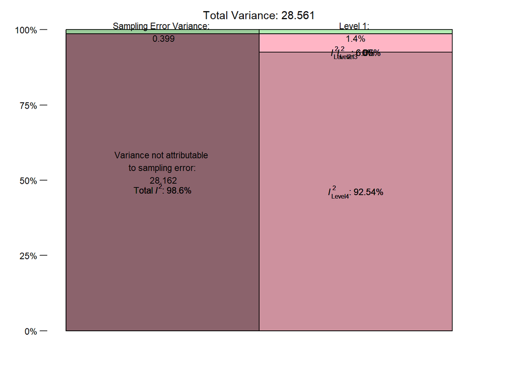

```
attr(,"class")
[1] "mlm.variance.distribution" "list"
```

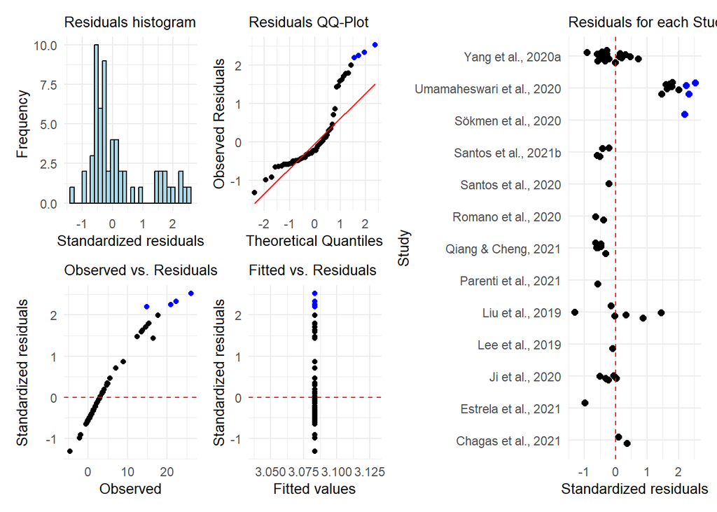

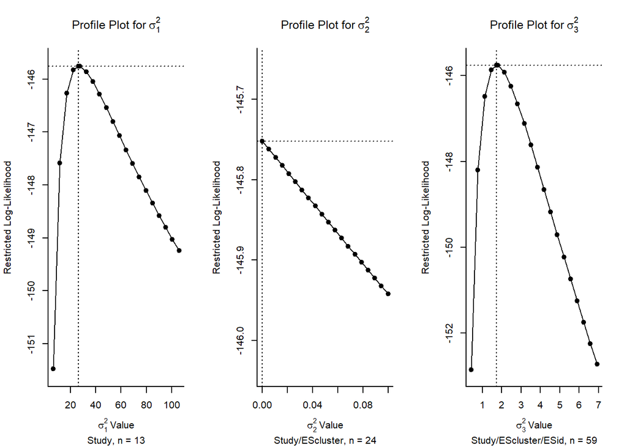

### Forest plot

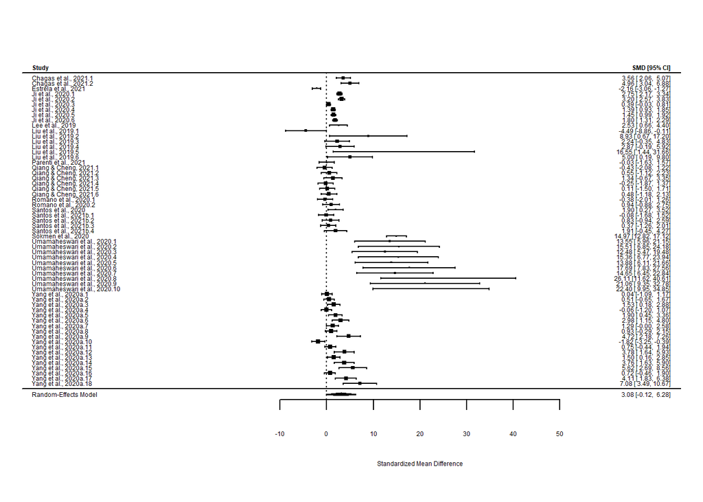

The meta-analysis comprised 59 comparisons from 24 control group clusters of 13 independent studies, so the random formula for ROS levels was ~1 | Study/EScluster/ESid.

No difference between treatment and control groups (ES = 3.083557 ± 1.4690942, CI95% = -0.1177969 to 6.284911, predicted interval -8.9156795 to 15.0827935), with high heterogeneity (i² = 98.6, Q = 605.9874968, p < 0.001 ) and variance explained by each component of $\sigma^2_{Study} = 26.43$, $\sigma^2_{EScluster} = 0.00$, $\sigma^2_{ESid} = 1.73$.

# Publication bias

> **Small-study effect:** when small studies (with small sample sizes) tend to report large effect sizes. (Yang et al. 2023)

> While the PET method works best when the true effect captured by β0β0 is **zero**, PEESE shows a better performance when the true effect is **not** zero. Stanley and Doucouliagos ([2014](https://bookdown.org/MathiasHarrer/Doing_Meta_Analysis_in_R/references.html#ref-stanley2014meta)) therefore proposed to combine both methods, in order to balance out their individual strengths. The resulting approach is the PET-PEESE method. PET-PEESE uses the intercept β0 of either PET or PEESE as the estimate of the corrected true effect.

> Whether PET or PEESE is used depends on the size of the intercept calculated by the PET method. When β0PET is significantly larger than zero in a one-sided test with α = 0.05, we use the intercept of PEESE as the true effect size estimate. If PET’s intercept is not significantly larger than zero, we remain with the PET estimate.

> In most implementations of regression models in *R*, it is conventional to test the significance of coefficients using a two-sided test (i.e. we test if a ββ weight significantly differs from zero, no matter the direction). To assume a one-sided test with α = 0.05, we already regard the intercept as significant when p < 0.1, and when the estimate of β0 is larger than zero<sup>38</sup>. (Harrer et al., n.d.)

> **Time-lag bias:** when statistically significant (“positive” results) tend to be published earlier than those with statistically non-significant findings (“negative” results), leading to a decline in reported effect sizes over time (i.e., a decline effect). (Yang et al. 2023)

> Given that high heterogeneity may invalidate publication bias test, it is best to account for the potential heterogeneity when testing publication bias. (Yang et al. 2023)

> PET-PEESE performs poorly in research areas where there are only a few studies, all studies use small samples, and where there is very high heterogeneity of results from study to study. Nonetheless, the statistical properties of conventional meta-analysis approaches are much worse than PET-PEESE under these same conditions.(Stanley 2017)

So, **better use meta-regression dataset**, but requires larger dataset to avoid possible convergence issues.

#### Plots

```
[1] "PEESE"
```

```
Multivariate Meta-Analysis Model (k = 59; method: REML)

   logLik   Deviance        AIC        BIC       AICc
-128.0683   256.1366   268.1366   280.2887   269.8509

Variance Components:

             estim    sqrt  nlvls  fixed                factor
sigma^2.1  15.7161  3.9644     13     no                 Study
sigma^2.2   0.0000  0.0001     24     no       Study/EScluster
sigma^2.3   1.3353  1.1556     59     no  Study/EScluster/ESid

Test for Residual Heterogeneity:
QE(df = 56) = 473.4323, p-val < .0001

Number of estimates:   59
Number of clusters:    13
Estimates per cluster: 0-18 (mean: 1.00, median: 0)

Test of Moderators (coefficients 2:3):¹
F(df1 = 2, df2 = 1.48) = 6.0219, p-val = 0.1948

Model Results:

          estimate         se¹     tval¹    df¹    pval¹       ci.lb¹
intrcpt  2821.6465  2174.0578    1.2979    5.1   0.2499   -2734.5278
vi          0.4198     0.0941    4.4607   1.13   0.1192      -0.5014
Year       -1.3956     1.0760   -1.2970    5.1   0.2502      -4.1452
             ci.ub¹
intrcpt  8377.8208
vi          1.3410
Year        1.3541

---
Signif. codes:  0 '***' 0.001 '**' 0.01 '*' 0.05 '.' 0.1 ' ' 1

1) results based on cluster-robust inference (var-cov estimator: CR2,
   approx t/F-tests and confidence intervals, df: Satterthwaite approx)
```

```
 pred   se ci.lb ci.ub pi.lb pi.ub
 2.43 1.16 -0.18  5.04 -7.22 12.08
```

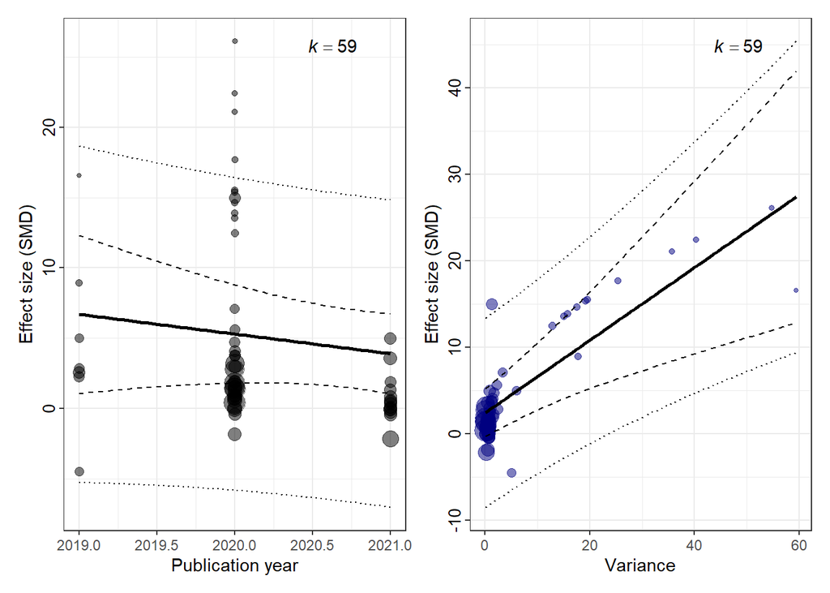

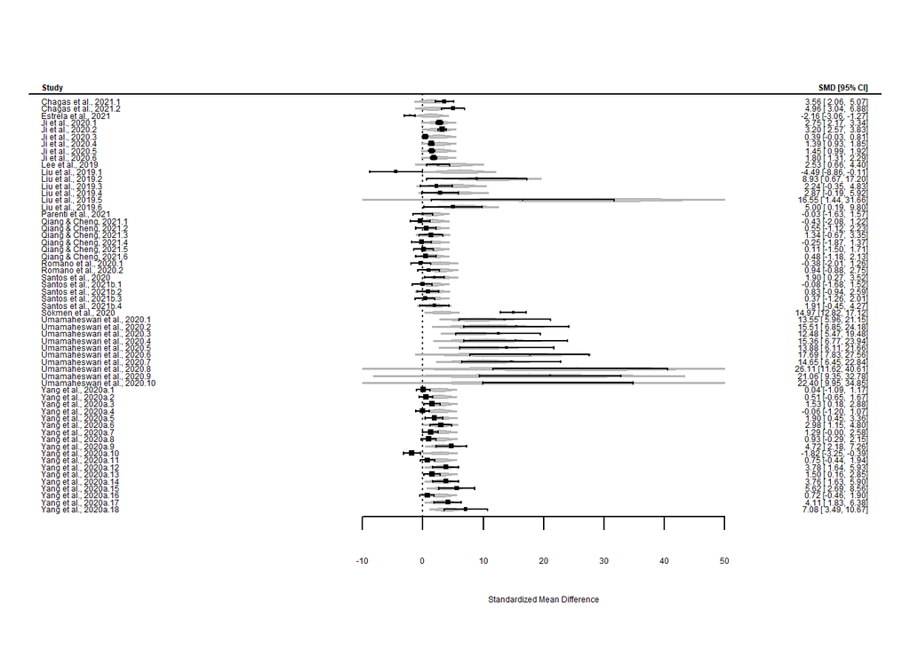

**Small-study effect** The regression slope of the extended Egger’s regression is $\sqrt{SMDSE} = 0.4198162$ is it statistically different from zero?`

If p<0.050: Smaller studies (with larger sampling error) have larger effect sizes –> small-study effect exists in this dataset. Data is assymmetrically distributed in the funnel plot.

If p>=0.050 no small-study effect exists in this dataset. Smaller studies (with larger sampling error) do not have larger effect sizes –> no small-study effect exists in this dataset. Data is symmetrically distributed in the funnel plot.

If p<0.050: studies with statistically significant findings tend to be published earlier than these with “negative” results, i.e. time-lag bias exists in this dataset

If p>=0.050: studies with statistically significant findings **do not** tend to be published earlier than these with “negative” results, i.e. no time-lag bias exists in this dataset

### Sensitivity analysis: publication bias with adapted SE

> Egger’s regression and its variants suffer from low power and poor performance when there are fewer than 20 effect sizes, or when the overall effect is large. (Nakagawa et al. 2022)

> Instead of the sample size (n1 + n2), however, for a meta-analysis of SMD or lnRR, we propose using the ‘effective sample size’ because it accounts for unbalanced sampling (cf. Stanley, 2005).(Nakagawa et al. 2022)

```r
if (mRE[[bias]]$pval[2] < 0.05) {

    # calculate modified SE based on effective sample size
    df$ess_vi <- with(df, sqrt((n_treat + n_ctrl)/(n_treat * n_ctrl)))
    df$ess_SE <- sqrt(df$ess_vi)  ## sampling error for ES

    # PET + year
    bias2 <- "PET sensitivity"
    mRE[[bias2]] <- rma.mv(yi, VCV, random = RE_formula, mods = ~ess_SE + Year, data = df,
        slab = Study, method = "REML", test = "t", dfs = "contain", level = 95)
    mRE[[bias2]] <- robust(mRE[[bias2]], cluster = df$Study, clubSandwich = TRUE)
    mRE[[bias2]] <- additional_results(mRE[[bias2]])
    mRE[[bias2]][["pi"]] <- predict(mRE[[bias2]], newmods = c(0, mean(df$Year)),
        digits = 2)

    # PEESE + year
    if (mRE[[bias2]]$pval[2] < 0.1) {
        mname <- "PEESE sensitivity"
        mRE[[mname]] <- rma.mv(yi, VCV, random = RE_formula, mods = ~ess_vi + Year,
            data = df, slab = Study, method = "REML", test = "t", dfs = "contain",
            level = 95)
        mRE[[mname]] <- robust(mRE[[mname]], cluster = df$Study, clubSandwich = TRUE)
        mRE[[mname]] <- additional_results(mRE[[mname]])
        mRE[[mname]][["pi"]] <- predict(mRE[[mname]], newmods = c(0, mean(df$Year)),
            digits = 2)
        bias2 <- mname
    }
}
```

If the results are the same, indicates the robustness of the small-study test.

#### Plots

# Sensitivity

## Rho range

```r
if (VCVrho != 0) {

    rho_range <- c(0, 0.25, 0.75, 0.9)  # assume a range values of rho

    for (j in 1:length(rho_range)) {

        mname <- paste("rho", rho_range[j], sep = "_")

        VCV2 <- vcalc(vi, cluster = interaction(df$EScluster, df$Study), obs = ESid,
            data = df, rho = rho_range[j])

        mRE[[mname]] <- rma.mv(yi, VCV2, random = RE_formula, data = df, slab = Study,
            method = "REML", test = "t", dfs = "contain", level = 95)
        mRE[[mname]] <- robust(mRE[[mname]], cluster = df$Study, clubSandwich = TRUE)
        mRE[[mname]] <- additional_results(mRE[[mname]])
    }
}
```

## Leave one out + Rho range

```r
if (VCVrho != 0) {
    rho_range <- c(0.25, 0.5, 0.75, 0.9)
} else {
    rho_range <- 0
}

for (i in sort(unique(df$Study))) {

    df_temp <- df[df$Study != i, ]

    for (j in 1:length(rho_range)) {

        mname <- paste("rho", rho_range[j], "l1o", i, sep = "_")
        print(mname)
        VCV2 <- vcalc(vi, cluster = interaction(df_temp$EScluster, df_temp$Study),
            obs = ESid, data = df_temp, rho = rho_range[j])

        mRE[[mname]] <- rma.mv(yi, VCV2, random = RE_formula, data = df_temp, slab = Study,
            method = "REML", test = "t", dfs = "contain", level = 95)
        mRE[[mname]] <- robust(mRE[[mname]], cluster = df_temp$Study, clubSandwich = TRUE)
        mRE[[mname]] <- additional_results(mRE[[mname]])
    }
}
```

```
[1] "rho_0.25_l1o_Chagas et al., 2021"
[1] "rho_0.5_l1o_Chagas et al., 2021"
[1] "rho_0.75_l1o_Chagas et al., 2021"
[1] "rho_0.9_l1o_Chagas et al., 2021"
[1] "rho_0.25_l1o_Estrela et al., 2021"
[1] "rho_0.5_l1o_Estrela et al., 2021"
[1] "rho_0.75_l1o_Estrela et al., 2021"
[1] "rho_0.9_l1o_Estrela et al., 2021"
[1] "rho_0.25_l1o_Ji et al., 2020"
[1] "rho_0.5_l1o_Ji et al., 2020"
[1] "rho_0.75_l1o_Ji et al., 2020"
[1] "rho_0.9_l1o_Ji et al., 2020"
[1] "rho_0.25_l1o_Lee et al., 2019"
[1] "rho_0.5_l1o_Lee et al., 2019"
[1] "rho_0.75_l1o_Lee et al., 2019"
```

[output cut: 37 more lines]

# Tables

|  | n studies | n ES clusters | n ES | overall effect | standard error | p-value | Lower CI | Upper CI | Lower PI | Upper PI | Q | Q p-value | $I^2$$_{total}$ | $I^2$$_{Study}$ | $I^2$$_{EScluster}$ | $I^2$$_{ES}$ | $\sigma^2$$_{Study}$ | $\sigma^2$$_{EScluster}$ | $\sigma^2$$_{ES}$ |
| --- | --- | --- | --- | --- | --- | --- | --- | --- | --- | --- | --- | --- | --- | --- | --- | --- | --- | --- | --- |
| ML | 13 | 24 | 59 | 3.08 | 1.5 | 0.0578 | -0.12 | 6.29 | -8.91 | 15.08 | 605.99 | 0 | 98.60 | 92.54 | 0.00 | 6.06 | 26.43 | 0.00 | 1.73 |
| ML_RobVar | 13 | 24 | 59 | 3.08 | 1.5 | 0.0577 | -0.12 | 6.28 | -8.92 | 15.08 | 605.99 | 0 | 98.60 | 92.54 | 0.00 | 6.06 | 26.43 | 0.00 | 1.73 |
| PET | 13 | 24 | 59 | 1534.91 | 2060.0 | 0.4893 | -3740.82 | 6810.64 | -10.31 | 8.25 | 421.55 | 0 | 97.31 | 92.84 | 0.00 | 4.46 | 13.74 | 0.00 | 0.66 |
| PEESE | 13 | 24 | 59 | 2821.65 | 2174.1 | 0.2499 | -2734.53 | 8377.82 | -7.22 | 12.08 | 473.43 | 0 | 97.71 | 90.06 | 0.00 | 7.65 | 15.72 | 0.00 | 1.34 |
| rho_0 | 13 | 24 | 59 | 3.33 | 1.5 | 0.0456 | 0.08 | 6.57 | -8.85 | 15.50 | 540.01 | 0 | 98.64 | 93.28 | 0.73 | 4.64 | 27.44 | 0.21 | 1.36 |
| rho_0.25 | 13 | 24 | 59 | 3.20 | 1.5 | 0.0515 | -0.02 | 6.43 | -8.88 | 15.28 | 542.84 | 0 | 98.62 | 93.64 | 0.00 | 4.98 | 27.10 | 0.00 | 1.44 |
| rho_0.75 | 13 | 24 | 59 | 2.94 | 1.4 | 0.0651 | -0.22 | 6.09 | -8.95 | 14.82 | 823.40 | 0 | 98.58 | 89.98 | 0.00 | 8.60 | 25.24 | 0.00 | 2.41 |
| rho_0.9 | 13 | 24 | 59 | 2.82 | 1.4 | 0.0705 | -0.28 | 5.92 | -8.92 | 14.57 | 1367.16 | 0 | 98.55 | 87.02 | 0.00 | 11.53 | 23.86 | 0.00 | 3.16 |
| rho_0.25_l1o_Chagas et al., 2021 | 12 | 23 | 57 | 3.13 | 1.6 | 0.0785 | -0.42 | 6.68 | -9.67 | 15.93 | 523.74 | 0 | 98.76 | 94.07 | 0.00 | 4.69 | 29.75 | 0.00 | 1.48 |
| rho_0.5_l1o_Chagas et al., 2021 | 12 | 23 | 57 | 3.00 | 1.6 | 0.0875 | -0.52 | 6.52 | -9.72 | 15.72 | 587.14 | 0 | 98.74 | 93.03 | 0.00 | 5.71 | 29.03 | 0.00 | 1.78 |
| rho_0.75_l1o_Chagas et al., 2021 | 12 | 23 | 57 | 2.85 | 1.6 | 0.0984 | -0.62 | 6.32 | -9.74 | 15.44 | 801.00 | 0 | 98.72 | 90.60 | 0.00 | 8.11 | 27.74 | 0.00 | 2.48 |
| rho_0.9_l1o_Chagas et al., 2021 | 12 | 23 | 57 | 2.72 | 1.5 | 0.1066 | -0.69 | 6.12 | -9.72 | 15.15 | 1333.74 | 0 | 98.69 | 87.82 | 0.00 | 10.86 | 26.25 | 0.00 | 3.25 |
| rho_0.25_l1o_Estrela et al., 2021 | 12 | 23 | 58 | 3.65 | 1.5 | 0.0371 | 0.26 | 7.03 | -8.56 | 15.86 | 483.56 | 0 | 98.59 | 93.59 | 0.00 | 5.01 | 26.97 | 0.00 | 1.44 |
| rho_0.5_l1o_Estrela et al., 2021 | 12 | 23 | 58 | 3.52 | 1.5 | 0.0419 | 0.15 | 6.88 | -8.64 | 15.67 | 554.38 | 0 | 98.58 | 92.51 | 0.00 | 6.07 | 26.41 | 0.00 | 1.73 |
| rho_0.75_l1o_Estrela et al., 2021 | 12 | 23 | 58 | 3.36 | 1.5 | 0.0479 | 0.04 | 6.67 | -8.71 | 15.42 | 788.33 | 0 | 98.56 | 89.98 | 0.00 | 8.58 | 25.34 | 0.00 | 2.42 |
| rho_0.9_l1o_Estrela et al., 2021 | 12 | 23 | 58 | 3.22 | 1.5 | 0.0524 | -0.04 | 6.48 | -8.72 | 15.16 | 1355.02 | 0 | 98.53 | 87.05 | 0.00 | 11.47 | 24.04 | 0.00 | 3.17 |
| rho_0.25_l1o_Ji et al., 2020 | 12 | 22 | 53 | 3.34 | 1.6 | 0.0630 | -0.22 | 6.90 | -9.48 | 16.16 | 440.53 | 0 | 97.30 | 92.09 | 0.00 | 5.22 | 29.65 | 0.00 | 1.68 |
| rho_0.5_l1o_Ji et al., 2020 | 12 | 22 | 53 | 3.22 | 1.6 | 0.0704 | -0.32 | 6.75 | -9.54 | 15.98 | 461.38 | 0 | 97.28 | 90.89 | 0.00 | 6.38 | 28.99 | 0.00 | 2.04 |
| rho_0.75_l1o_Ji et al., 2020 | 12 | 22 | 53 | 3.07 | 1.6 | 0.0793 | -0.42 | 6.56 | -9.61 | 15.74 | 566.51 | 0 | 97.24 | 88.26 | 0.00 | 8.98 | 27.81 | 0.00 | 2.83 |
| rho_0.9_l1o_Ji et al., 2020 | 12 | 22 | 53 | 2.95 | 1.6 | 0.0859 | -0.49 | 6.39 | -9.61 | 15.52 | 866.28 | 0 | 97.20 | 85.46 | 0.00 | 11.74 | 26.49 | 0.00 | 3.64 |
| rho_0.25_l1o_Lee et al., 2019 | 12 | 23 | 58 | 3.27 | 1.6 | 0.0675 | -0.28 | 6.81 | -9.53 | 16.06 | 541.06 | 0 | 98.75 | 94.18 | 0.00 | 4.57 | 29.76 | 0.00 | 1.44 |
| rho_0.5_l1o_Lee et al., 2019 | 12 | 23 | 58 | 3.14 | 1.6 | 0.0754 | -0.38 | 6.65 | -9.58 | 15.85 | 603.44 | 0 | 98.73 | 93.18 | 0.00 | 5.55 | 29.09 | 0.00 | 1.73 |
| rho_0.75_l1o_Lee et al., 2019 | 12 | 23 | 58 | 2.98 | 1.6 | 0.0847 | -0.48 | 6.45 | -9.61 | 15.58 | 818.59 | 0 | 98.71 | 90.82 | 0.00 | 7.89 | 27.83 | 0.00 | 2.42 |
| rho_0.9_l1o_Lee et al., 2019 | 12 | 23 | 58 | 2.86 | 1.5 | 0.0916 | -0.54 | 6.26 | -9.58 | 15.29 | 1356.16 | 0 | 98.68 | 88.08 | 0.00 | 10.60 | 26.36 | 0.00 | 3.17 |
| rho_0.25_l1o_Liu et al., 2019 | 12 | 23 | 53 | 3.36 | 1.6 | 0.0609 | -0.18 | 6.89 | -9.38 | 16.09 | 522.14 | 0 | 98.84 | 94.87 | 0.00 | 3.97 | 29.65 | 0.00 | 1.24 |
| rho_0.5_l1o_Liu et al., 2019 | 12 | 23 | 53 | 3.30 | 1.6 | 0.0617 | -0.19 | 6.79 | -9.26 | 15.85 | 576.49 | 0 | 98.81 | 94.45 | 0.00 | 4.36 | 28.70 | 0.00 | 1.32 |
| rho_0.75_l1o_Liu et al., 2019 | 12 | 23 | 53 | 3.21 | 1.5 | 0.0617 | -0.19 | 6.61 | -9.01 | 15.43 | 767.42 | 0 | 98.74 | 93.64 | 0.00 | 5.10 | 26.96 | 0.00 | 1.47 |
| rho_0.9_l1o_Liu et al., 2019 | 12 | 23 | 53 | 3.10 | 1.5 | 0.0605 | -0.16 | 6.36 | -8.63 | 14.83 | 1233.15 | 0 | 98.64 | 92.47 | 0.00 | 6.17 | 24.56 | 0.00 | 1.64 |
| rho_0.25_l1o_Parenti et al., 2021 | 12 | 23 | 58 | 3.47 | 1.6 | 0.0511 | -0.02 | 6.96 | -9.13 | 16.07 | 540.29 | 0 | 98.71 | 94.00 | 0.00 | 4.71 | 28.82 | 0.00 | 1.44 |
| rho_0.5_l1o_Parenti et al., 2021 | 12 | 23 | 58 | 3.34 | 1.6 | 0.0574 | -0.12 | 6.81 | -9.19 | 15.88 | 604.32 | 0 | 98.69 | 92.98 | 0.00 | 5.71 | 28.21 | 0.00 | 1.73 |
| rho_0.75_l1o_Parenti et al., 2021 | 12 | 23 | 58 | 3.19 | 1.6 | 0.0650 | -0.23 | 6.61 | -9.24 | 15.61 | 823.04 | 0 | 98.67 | 90.58 | 0.00 | 8.10 | 27.04 | 0.00 | 2.42 |
| rho_0.9_l1o_Parenti et al., 2021 | 12 | 23 | 58 | 3.05 | 1.5 | 0.0705 | -0.30 | 6.41 | -9.23 | 15.34 | 1366.63 | 0 | 98.64 | 87.79 | 0.00 | 10.86 | 25.65 | 0.00 | 3.17 |
| rho_0.25_l1o_Qiang & Cheng, 2021 | 12 | 22 | 53 | 3.48 | 1.6 | 0.0519 | -0.03 | 6.99 | -9.20 | 16.16 | 533.42 | 0 | 98.77 | 92.88 | 0.00 | 5.90 | 28.81 | 0.00 | 1.83 |
| rho_0.5_l1o_Qiang & Cheng, 2021 | 12 | 22 | 53 | 3.35 | 1.6 | 0.0581 | -0.14 | 6.84 | -9.27 | 15.97 | 598.40 | 0 | 98.76 | 91.72 | 0.00 | 7.04 | 28.19 | 0.00 | 2.16 |
| rho_0.75_l1o_Qiang & Cheng, 2021 | 12 | 22 | 53 | 3.21 | 1.6 | 0.0655 | -0.24 | 6.66 | -9.33 | 15.75 | 814.14 | 0 | 98.75 | 89.11 | 0.00 | 9.64 | 27.06 | 0.00 | 2.93 |
| rho_0.9_l1o_Qiang & Cheng, 2021 | 12 | 22 | 53 | 3.09 | 1.5 | 0.0709 | -0.31 | 6.49 | -9.34 | 15.52 | 1346.44 | 0 | 98.73 | 86.28 | 0.00 | 12.44 | 25.78 | 0.00 | 3.72 |
| rho_0.25_l1o_Romano et al., 2020 | 12 | 23 | 57 | 3.46 | 1.6 | 0.0527 | -0.05 | 6.97 | -9.19 | 16.11 | 538.90 | 0 | 98.73 | 93.90 | 0.00 | 4.82 | 28.98 | 0.00 | 1.49 |
| rho_0.5_l1o_Romano et al., 2020 | 12 | 23 | 57 | 3.33 | 1.6 | 0.0591 | -0.15 | 6.81 | -9.25 | 15.91 | 602.43 | 0 | 98.71 | 92.86 | 0.00 | 5.85 | 28.37 | 0.00 | 1.79 |
| rho_0.75_l1o_Romano et al., 2020 | 12 | 23 | 57 | 3.18 | 1.6 | 0.0669 | -0.26 | 6.61 | -9.30 | 15.66 | 818.74 | 0 | 98.70 | 90.42 | 0.00 | 8.28 | 27.21 | 0.00 | 2.49 |
| rho_0.9_l1o_Romano et al., 2020 | 12 | 23 | 57 | 3.05 | 1.5 | 0.0725 | -0.33 | 6.43 | -9.30 | 15.40 | 1356.48 | 0 | 98.67 | 87.62 | 0.00 | 11.05 | 25.84 | 0.00 | 3.26 |
| rho_0.25_l1o_Santos et al., 2020 | 12 | 23 | 58 | 3.32 | 1.6 | 0.0636 | -0.22 | 6.86 | -9.46 | 16.09 | 542.25 | 0 | 98.74 | 94.16 | 0.00 | 4.58 | 29.66 | 0.00 | 1.44 |
| rho_0.5_l1o_Santos et al., 2020 | 12 | 23 | 58 | 3.19 | 1.6 | 0.0710 | -0.32 | 6.70 | -9.51 | 15.89 | 604.85 | 0 | 98.73 | 93.16 | 0.00 | 5.57 | 29.01 | 0.00 | 1.73 |
| rho_0.75_l1o_Santos et al., 2020 | 12 | 23 | 58 | 3.03 | 1.6 | 0.0800 | -0.43 | 6.50 | -9.55 | 15.62 | 820.32 | 0 | 98.70 | 90.80 | 0.00 | 7.90 | 27.77 | 0.00 | 2.42 |
| rho_0.9_l1o_Santos et al., 2020 | 12 | 23 | 58 | 2.91 | 1.5 | 0.0865 | -0.49 | 6.30 | -9.52 | 15.33 | 1357.84 | 0 | 98.67 | 88.06 | 0.00 | 10.61 | 26.31 | 0.00 | 3.17 |
| rho_0.25_l1o_Santos et al., 2021b | 12 | 20 | 55 | 3.43 | 1.6 | 0.0552 | -0.09 | 6.96 | -9.28 | 16.15 | 538.33 | 0 | 98.76 | 93.59 | 0.00 | 5.17 | 29.17 | 0.00 | 1.61 |
| rho_0.5_l1o_Santos et al., 2021b | 12 | 20 | 55 | 3.31 | 1.6 | 0.0619 | -0.20 | 6.81 | -9.34 | 15.96 | 602.92 | 0 | 98.75 | 92.53 | 0.00 | 6.22 | 28.57 | 0.00 | 1.92 |
| rho_0.75_l1o_Santos et al., 2021b | 12 | 20 | 55 | 3.16 | 1.6 | 0.0700 | -0.31 | 6.62 | -9.40 | 15.71 | 821.33 | 0 | 98.74 | 90.05 | 0.00 | 8.69 | 27.42 | 0.00 | 2.65 |
| rho_0.9_l1o_Santos et al., 2021b | 12 | 20 | 55 | 3.03 | 1.5 | 0.0760 | -0.38 | 6.44 | -9.40 | 15.47 | 1358.05 | 0 | 98.71 | 87.26 | 0.00 | 11.45 | 26.09 | 0.00 | 3.42 |
| rho_0.25_l1o_Sökmen et al., 2020 | 12 | 23 | 58 | 2.23 | 1.2 | 0.0915 | -0.43 | 4.88 | -7.37 | 11.83 | 385.63 | 0 | 97.80 | 89.96 | 0.00 | 7.84 | 16.14 | 0.00 | 1.41 |
| rho_0.5_l1o_Sökmen et al., 2020 | 12 | 23 | 58 | 2.09 | 1.2 | 0.1017 | -0.49 | 4.68 | -7.27 | 11.45 | 442.76 | 0 | 97.69 | 87.84 | 0.00 | 9.85 | 15.01 | 0.00 | 1.68 |
| rho_0.75_l1o_Sökmen et al., 2020 | 12 | 23 | 58 | 1.94 | 1.1 | 0.1146 | -0.55 | 4.44 | -7.19 | 11.08 | 646.59 | 0 | 97.58 | 83.31 | 0.00 | 14.27 | 13.58 | 0.00 | 2.33 |
| rho_0.9_l1o_Sökmen et al., 2020 | 12 | 23 | 58 | 1.82 | 1.1 | 0.1246 | -0.59 | 4.24 | -7.12 | 10.77 | 1163.75 | 0 | 97.48 | 78.27 | 0.00 | 19.21 | 12.27 | 0.00 | 3.01 |
| rho_0.25_l1o_Umamaheswari et al., 2020 | 12 | 19 | 49 | 2.19 | 1.2 | 0.0853 | -0.36 | 4.73 | -7.06 | 11.44 | 458.58 | 0 | 98.01 | 88.80 | 0.00 | 9.21 | 14.78 | 0.00 | 1.53 |
| rho_0.5_l1o_Umamaheswari et al., 2020 | 12 | 19 | 49 | 2.09 | 1.2 | 0.0984 | -0.46 | 4.64 | -7.20 | 11.38 | 533.45 | 0 | 98.03 | 87.06 | 0.00 | 10.97 | 14.63 | 0.00 | 1.84 |
| rho_0.75_l1o_Umamaheswari et al., 2020 | 12 | 19 | 49 | 1.98 | 1.2 | 0.1141 | -0.56 | 4.52 | -7.38 | 11.34 | 756.61 | 0 | 98.06 | 83.09 | 0.00 | 14.97 | 14.17 | 0.00 | 2.55 |
| rho_0.9_l1o_Umamaheswari et al., 2020 | 12 | 19 | 49 | 1.90 | 1.1 | 0.1271 | -0.63 | 4.43 | -7.53 | 11.33 | 1297.18 | 0 | 98.09 | 79.44 | 0.00 | 18.65 | 13.77 | 0.00 | 3.23 |
| rho_0.25_l1o_Yang et al., 2020a | 12 | 21 | 41 | 3.34 | 1.6 | 0.0624 | -0.21 | 6.89 | -9.37 | 16.05 | 455.07 | 0 | 98.84 | 96.68 | 0.00 | 2.16 | 30.07 | 0.00 | 0.67 |
| rho_0.5_l1o_Yang et al., 2020a | 12 | 21 | 41 | 3.23 | 1.6 | 0.0686 | -0.29 | 6.75 | -9.39 | 15.84 | 487.76 | 0 | 98.82 | 95.88 | 0.00 | 2.94 | 29.38 | 0.00 | 0.90 |
| rho_0.75_l1o_Yang et al., 2020a | 12 | 21 | 41 | 3.09 | 1.6 | 0.0767 | -0.39 | 6.56 | -9.48 | 15.65 | 622.07 | 0 | 98.82 | 91.77 | 0.00 | 7.05 | 27.92 | 0.00 | 2.14 |
| rho_0.9_l1o_Yang et al., 2020a | 12 | 21 | 41 | 2.98 | 1.6 | 0.0827 | -0.46 | 6.42 | -9.55 | 15.51 | 990.20 | 0 | 98.81 | 87.22 | 0.00 | 11.59 | 26.42 | 0.00 | 3.51 |

|  | ML | ML_RobVar | PET | PEESE | rho_0 | rho_0.25 | rho_0.75 | rho_0.9 | rho_0.25_l1o_Chagas.et.al...2021 | rho_0.5_l1o_Chagas.et.al...2021 | rho_0.75_l1o_Chagas.et.al...2021 | rho_0.9_l1o_Chagas.et.al...2021 | rho_0.25_l1o_Estrela.et.al...2021 | rho_0.5_l1o_Estrela.et.al...2021 | rho_0.75_l1o_Estrela.et.al...2021 | rho_0.9_l1o_Estrela.et.al...2021 | rho_0.25_l1o_Ji.et.al...2020 | rho_0.5_l1o_Ji.et.al...2020 | rho_0.75_l1o_Ji.et.al...2020 | rho_0.9_l1o_Ji.et.al...2020 | rho_0.25_l1o_Lee.et.al...2019 | rho_0.5_l1o_Lee.et.al...2019 | rho_0.75_l1o_Lee.et.al...2019 | rho_0.9_l1o_Lee.et.al...2019 | rho_0.25_l1o_Liu.et.al...2019 | rho_0.5_l1o_Liu.et.al...2019 | rho_0.75_l1o_Liu.et.al...2019 | rho_0.9_l1o_Liu.et.al...2019 | rho_0.25_l1o_Parenti.et.al...2021 | … |
| --- | --- | --- | --- | --- | --- | --- | --- | --- | --- | --- | --- | --- | --- | --- | --- | --- | --- | --- | --- | --- | --- | --- | --- | --- | --- | --- | --- | --- | --- | --- |
| logLik: | -145.7518362734375 | -145.7518362734375 | -118.8578039802475 | -128.0682965165893 | -145.5178755044186 | -145.1126973479811 | -147.4881290909833 | -149.1270832817253 | -140.5973990329573 | -141.2255389717141 | -142.9059677173699 | -144.4823134210106 | -141.941180540978 | -142.6041468885234 | -144.369724649403 | -146.0332317508843 | -134.2209998642074 | -134.6872518823865 | -136.0101251543983 | -137.2534559781568 | -142.4428683333263 | -143.0907827871463 | -144.8389385131407 | -146.4913453576014 | -123.3443060131407 | -122.586100152793 | -122.2937288597562 | -122.8184855682946 | -142.2737708661349 | … |
| deviance: | 291.503672546875 | 291.503672546875 | 237.715607960495 | 256.1365930331785 | 291.0357510088371 | 290.2253946959622 | 294.9762581819666 | 298.2541665634507 | 281.1947980659147 | 282.4510779434282 | 285.8119354347399 | 288.9646268420212 | 283.882361081956 | 285.2082937770468 | 288.739449298806 | 292.0664635017686 | 268.4419997284149 | 269.374503764773 | 272.0202503087966 | 274.5069119563137 | 284.8857366666527 | 286.1815655742926 | 289.6778770262814 | 292.9826907152029 | 246.6886120262814 | 245.1722003055859 | 244.5874577195124 | 245.6369711365892 | 284.5475417322698 | … |
| AIC: | 299.503672546875 | 299.503672546875 | 249.715607960495 | 268.1365930331785 | 299.0357510088371 | 298.2253946959622 | 302.9762581819666 | 306.2541665634507 | 289.1947980659147 | 290.4510779434282 | 293.8119354347399 | 296.9646268420212 | 291.882361081956 | 293.2082937770468 | 296.739449298806 | 300.0664635017686 | 276.4419997284149 | 277.374503764773 | 280.0202503087966 | 282.5069119563137 | 292.8857366666527 | 294.1815655742926 | 297.6778770262814 | 300.9826907152029 | 254.6886120262814 | 253.1722003055859 | 252.5874577195124 | 253.6369711365892 | 292.5475417322698 | … |
| BIC: | 307.7454445890607 | 307.7454445890607 | 261.8677181049059 | 280.2887031775895 | 307.2775230510228 | 306.4671667381479 | 311.2180302241522 | 314.4959386056364 | 297.2962048288553 | 298.5524847063688 | 301.9133421976805 | 305.0660336049618 | 300.0545661532942 | 301.3804988483851 | 304.9116543701442 | 308.2386685731068 | 284.2469746027406 | 285.1794786390987 | 287.8252251831223 | 290.3118868306394 | 301.0579417379909 | 302.3537706456308 | 305.8500820976196 | 309.1548957865411 | 262.4935869006071 | 260.9771751799116 | 260.3924325938381 | 261.4419460109149 | 300.719746803608 | … |
| AICc: | 300.2583895280071 | 300.2583895280071 | 251.4298936747807 | 269.8508787474643 | 299.7904679899692 | 298.9801116770942 | 303.7309751630986 | 307.0088835445827 | 289.9791117914049 | 291.2353916689185 | 294.5962491602301 | 297.7489405675115 | 292.6515918511868 | 293.9775245462776 | 297.5086800680368 | 300.8356942709993 | 277.2930635582021 | 278.2255675945602 | 280.8713141385838 | 283.3579757861009 | 293.6549674358835 | 294.9507963435234 | 298.4471077955122 | 301.7519214844336 | 255.5396758560686 | 254.0232641353732 | 253.4385215492997 | 254.4880349663764 | 293.3167725015006 | … |

# Influential cases

> Outliers and influential cases can actually reveal patterns that may lead to new insights about study characteristics that could be acting as potential moderators (Viechtbauer and Cheung 2010)

Cook’s distance: examine what effect the deletion of the ith study has on the fitted values of all k studies simultaneously (Viechtbauer and Cheung 2010)

DFBETAS: directly examine the influence of deleting the ith case on each individual parameter estimate (Viechtbauer and Cheung 2010)

So if a point has high Cook’s Distance, use DFBETAS to identify witch estimate is mainly influenced (only makes sense for meta regression).

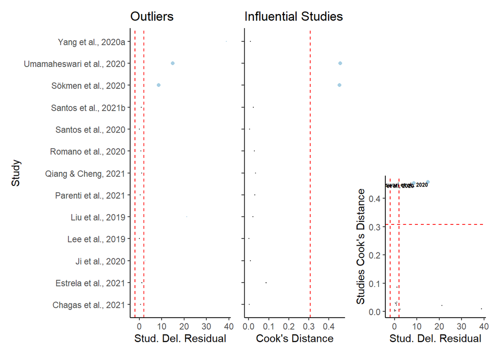

```r
influentialcases_plots(mRE, "ML_RobVar", "ML", 3)
```

# Multilevel meta-regression

SYRCLE PROTOCOL: Meta-regression will be used for outcomes with at least 10 experiments.

> The minimal number of studies or effect sizes required by a multilevel meta-regression remains unknown, albeit some simulation studies suggest that the estimates of model coefficients of a multilevel meta-regression are generally stable under various simulated situations.(Yang et al. 2023) … the complexity of parameterization of such a meta-regression requires a large dataset to make optimization algorithms free of convergence issues.(Yang et al. 2023)

## Model 1: Size, Duration, Development

```r
df_MR <- select(df, c("Year", "StudyID", "Study", "EScluster", "ESid", "DevelopmentalStage",
    "ExposureDurationDays", "ParticleSizeMean", "yi", "vi"))

mname1 <- "Base"
mname2 <- paste0(mname1, "_RobVar")

# are there differences between the different forms of DevelopmentalStage?
# mods_formula <- formula(~ ParticleSizeMean +
# ExposureDurationDays*DevelopmentalStage) at least one of the
# DevelopmentalStage levels is different than zero?
mods_formula <- formula(~0 + ParticleSizeMean + ExposureDurationDays * DevelopmentalStage)

mMR[[mname1]] <- rma.mv(yi, VCV, random = RE_formula, mods = mods_formula, data = df_MR,
    slab = Study, method = "REML", test = "t", dfs = "contain", level = 95)  #it will only keep complete cases

nSt_MR <- mMR[[mname1]]$s.nlevels[1]  # number of studies
nEC_MR <- mMR[[mname1]]$s.nlevels[2]  # number of ESclusters
nES_MR <- mMR[[mname1]]$s.nlevels[3]  # number of independent ES

print(paste0("Number of studies: ", nSt_MR, ", number of ES clusters: ", nEC_MR,
    " and number of independent observations of ES: ", nES_MR))
```

```
[1] "Number of studies: 12, number of ES clusters: 23 and number of independent observations of ES: 57"
```

```r
mMR[[mname2]] <- robust(mMR[[mname1]], cluster = df_MR$Study, clubSandwich = TRUE,
    verbose = TRUE)
```

```
Error in Wald_testing(C_mat = constraints, beta = beta, vcov = vcov, test = test,  :
  Variance-covariance matrix of the contrast is not positive definite. The test cannot be computed.
```

```r
mMR[[mname2]][["i2"]] <- i2_ml(mMR[[mname2]])
mMR[[mname2]][["icc"]] <- round(mMR[[mname2]]$sigma2/sum(mMR[[mname2]]$sigma2), 3)

anova(mMR[[mname2]], btt = c("DevelopmentalStage", "ExposureDurationDays", "ParticleSizeMean"))
```

```
                  spec coefs   Fval df1   df2   pval
1   DevelopmentalStage   3:7 0.0000   5 -0.93     NA
2 ExposureDurationDays   2,7 4.7799   2  0.54 0.4541
3     ParticleSizeMean     1 0.0781   1  1.02 0.8258
```

The meta-regression comprised 57 comparisons from 23 control group clusters of 12 independent studies.

#### Diagnostics plots

```
Multivariate Meta-Analysis Model (k = 57; method: REML)

   logLik   Deviance        AIC        BIC       AICc
-123.9508   247.9016   267.9016   287.0218   273.5426

Variance Components:

             estim    sqrt  nlvls  fixed                factor
sigma^2.1  34.8056  5.8996     12     no                 Study
sigma^2.2   0.0000  0.0001     23     no       Study/EScluster
sigma^2.3   1.9648  1.4017     57     no  Study/EScluster/ESid

Test for Residual Heterogeneity:
QE(df = 50) = 515.2309, p-val < .0001

Number of estimates:   57
Number of clusters:    12
Estimates per cluster: 0-18 (mean: 0.97, median: 0)

Model Results:

                                              estimate       se¹      tval¹
ParticleSizeMean                               -0.0608   0.2175    -0.2794
ExposureDurationDays                            0.1484   0.0329     4.5160
DevelopmentalStageEmbrio                        5.4218  10.8745     0.4986
DevelopmentalStageLarva                         2.0648   2.0620     1.0013
DevelopmentalStageJuvenile                     -2.6062   0.0984   -26.4877
DevelopmentalStageAdult                         3.0232   5.0003     0.6046
ExposureDurationDays:DevelopmentalStageLarva    0.0392   0.0897     0.4378
                                                df¹    pval¹      ci.lb¹
ParticleSizeMean                              1.02   0.8258     -2.6956
ExposureDurationDays                          1.04   0.1322     -0.2366
DevelopmentalStageEmbrio                      1.02   0.7041   -125.8746
DevelopmentalStageLarva                       5.78   0.3567     -3.0280
DevelopmentalStageJuvenile                    1.04   0.0215     -3.7590
DevelopmentalStageAdult                       1.08   0.6478    -50.6361
ExposureDurationDays:DevelopmentalStageLarva  1.89   0.7064     -0.3684
                                                 ci.ub¹
ParticleSizeMean                                2.5740
ExposureDurationDays                            0.5334
DevelopmentalStageEmbrio                      136.7182
DevelopmentalStageLarva                         7.1575
DevelopmentalStageJuvenile                     -1.4533   *
DevelopmentalStageAdult                        56.6825
ExposureDurationDays:DevelopmentalStageLarva    0.4469

---
Signif. codes:  0 '***' 0.001 '**' 0.01 '*' 0.05 '.' 0.1 ' ' 1

1) results based on cluster-robust inference (var-cov estimator: CR2,
   approx t/F-tests and confidence intervals, df: Satterthwaite approx)
```

|  | ML | REML |
| --- | --- | --- |
| ll | -142.6468 | -123.9508 |
| dev | 178.9558 | 247.9016 |
| AIC | 305.2936 | 267.9016 |
| BIC | 325.7241 | 287.0218 |
| AICc | 310.0762 | 273.5426 |

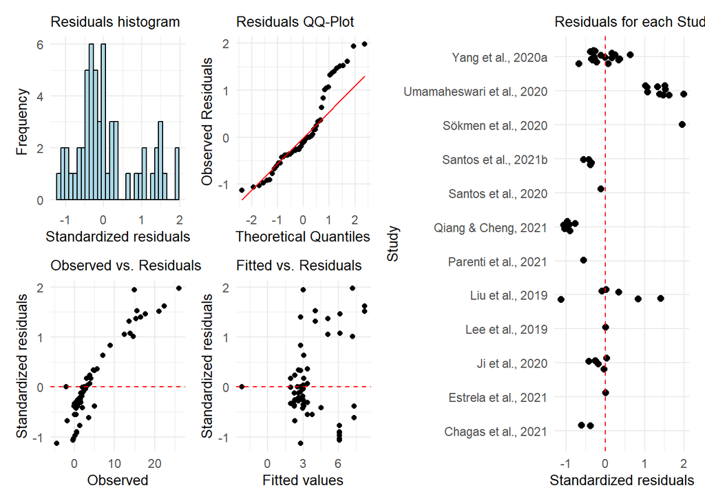

#### Influential cases

#### Orchard plots

(Nakagawa et al. 2021)

## Model 2: + Concentration

```r
df_MR <- select(df, c("Year", "StudyID", "Study", "EScluster", "ESid", "DevelopmentalStage",
    "ExposureDurationDays", "ParticleSizeMean", "Concentration_mg_L", "yi", "vi"))

mname1 <- "Conc+"
mname2 <- paste0(mname1, "_RobVar")

mods_formula <- formula(~0 + ParticleSizeMean + Concentration_mg_L + ExposureDurationDays *
    DevelopmentalStage)

mMR[[mname1]] <- rma.mv(yi, VCV, random = RE_formula, mods = mods_formula, data = df_MR,
    slab = Study, method = "REML", test = "t", dfs = "contain", level = 95)  #it will only keep complete cases

nSt_MR <- mMR[[mname1]]$s.nlevels[1]  # number of studies
nEC_MR <- mMR[[mname1]]$s.nlevels[2]  # number of ESclusters
nES_MR <- mMR[[mname1]]$s.nlevels[3]  # number of independent ES

print(paste0("Number of studies: ", nSt_MR, ", number of ES clusters: ", nEC_MR,
    " and number of independent observations of ES: ", nES_MR))
```

```
[1] "Number of studies: 12, number of ES clusters: 23 and number of independent observations of ES: 57"
```

```r
mMR[[mname2]] <- robust(mMR[[mname1]], cluster = df_MR$Study, clubSandwich = TRUE,
    verbose = TRUE)
```

```
Error in Wald_testing(C_mat = constraints, beta = beta, vcov = vcov, test = test,  :
  Variance-covariance matrix of the contrast is not positive definite. The test cannot be computed.
```

```r
mMR[[mname2]][["i2"]] <- i2_ml(mMR[[mname2]])
mMR[[mname2]][["icc"]] <- round(mMR[[mname2]]$sigma2/sum(mMR[[mname2]]$sigma2), 3)

anova(mMR[[mname2]], btt = c("DevelopmentalStage", "ExposureDurationDays", "ParticleSizeMean",
    "Concentration_mg_L"))
```

```
                  spec coefs   Fval df1   df2   pval
1   DevelopmentalStage   4:8 0.0000   5 -0.24     NA
2 ExposureDurationDays   3,8 1.4165   2  0.52 0.6146
3     ParticleSizeMean     1 0.0911   1  1.01 0.8131
4   Concentration_mg_L     2 3.1572   1  3.04 0.1725
```

The meta-regression comprised 57 comparisons from 23 control group clusters of 12 independent studies.

#### Diagnostics plots

```
Multivariate Meta-Analysis Model (k = 57; method: REML)

   logLik   Deviance        AIC        BIC       AICc
-116.4171   232.8342   254.8342   275.6442   261.9693

Variance Components:

             estim    sqrt  nlvls  fixed                factor
sigma^2.1  71.4799  8.4546     12     no                 Study
sigma^2.2   0.0000  0.0001     23     no       Study/EScluster
sigma^2.3   1.1403  1.0678     57     no  Study/EScluster/ESid

Test for Residual Heterogeneity:
QE(df = 49) = 514.2716, p-val < .0001

Number of estimates:   57
Number of clusters:    12
Estimates per cluster: 0-18 (mean: 0.97, median: 0)

Model Results:

                                               estimate       se¹     tval¹
ParticleSizeMean                                -0.0526   0.1744   -0.3018
Concentration_mg_L                               1.4117   0.7945    1.7768
ExposureDurationDays                             0.1544   0.1067    1.4476
DevelopmentalStageEmbrio                      -136.1632  86.6825   -1.5708
DevelopmentalStageLarva                         -0.9359   3.4710   -0.2696
DevelopmentalStageJuvenile                      -3.6973   0.6835   -5.4093
DevelopmentalStageAdult                          1.0451   3.4933    0.2992
ExposureDurationDays:DevelopmentalStageLarva     0.0290   0.1345    0.2155
                                                df¹    pval¹      ci.lb¹
ParticleSizeMean                              1.01   0.8131     -2.2231
Concentration_mg_L                            3.04   0.1725     -1.0981
ExposureDurationDays                          1.02   0.3814     -1.1391
DevelopmentalStageEmbrio                      3.03   0.2133   -410.3816
DevelopmentalStageLarva                       6.01   0.7965     -9.4257
DevelopmentalStageJuvenile                    1.57   0.0534     -7.5603
DevelopmentalStageAdult                       1.24   0.8073    -27.6077
ExposureDurationDays:DevelopmentalStageLarva  1.72   0.8521     -0.6489
                                                 ci.ub¹
ParticleSizeMean                                2.1179
Concentration_mg_L                              3.9215
ExposureDurationDays                            1.4479
DevelopmentalStageEmbrio                      138.0552
DevelopmentalStageLarva                         7.5540
DevelopmentalStageJuvenile                      0.1658   .
DevelopmentalStageAdult                        29.6980
ExposureDurationDays:DevelopmentalStageLarva    0.7069

---
Signif. codes:  0 '***' 0.001 '**' 0.01 '*' 0.05 '.' 0.1 ' ' 1

1) results based on cluster-robust inference (var-cov estimator: CR2,
   approx t/F-tests and confidence intervals, df: Satterthwaite approx)
```

|  | ML | REML |
| --- | --- | --- |
| ll | -139.1714 | -116.4171 |
| dev | 172.0050 | 232.8342 |
| AIC | 300.3428 | 254.8342 |
| BIC | 322.8164 | 275.6442 |
| AICc | 306.2095 | 261.9693 |

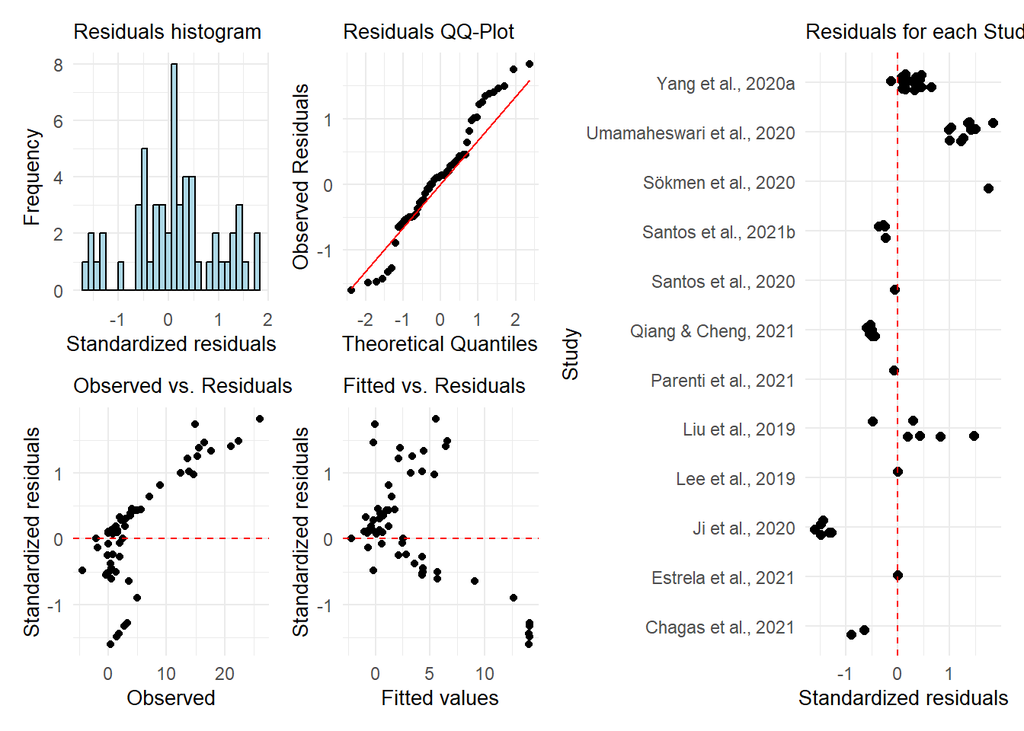

#### Influential cases

#### Orchard plots

## Model 3: + ParticleMaterial

```r
df_MR <- select(df, c("Year", "StudyID", "Study", "EScluster", "ESid", "DevelopmentalStage",
    "ExposureDurationDays", "ParticleSizeMean", "ParticleMaterial", "yi", "vi"))

mname1 <- "PartMat+"
mname2 <- paste0(mname1, "_RobVar")

mods_formula <- formula(~(ParticleSizeMean + ExposureDurationDays * DevelopmentalStage +
    ParticleMaterial))

mMR[[mname1]] <- rma.mv(yi, VCV, random = RE_formula, mods = mods_formula, data = df_MR,
    slab = Study, method = "REML", test = "t", dfs = "contain", level = 95)  #it will only keep complete cases

nSt_MR <- mMR[[mname1]]$s.nlevels[1]  # number of studies
nEC_MR <- mMR[[mname1]]$s.nlevels[2]  # number of ESclusters
nES_MR <- mMR[[mname1]]$s.nlevels[3]  # number of independent ES

print(paste0("Number of studies: ", nSt_MR, ", number of ES clusters: ", nEC_MR,
    " and number of independent observations of ES: ", nES_MR))
```

```
[1] "Number of studies: 12, number of ES clusters: 23 and number of independent observations of ES: 57"
```

```r
mMR[[mname2]] <- robust(mMR[[mname1]], cluster = df_MR$Study, clubSandwich = TRUE,
    verbose = TRUE)

mMR[[mname2]][["i2"]] <- i2_ml(mMR[[mname2]])
mMR[[mname2]][["icc"]] <- round(mMR[[mname2]]$sigma2/sum(mMR[[mname2]]$sigma2), 3)

anova(mMR[[mname2]], btt = c("DevelopmentalStage", "ExposureDurationDays", "ParticleSizeMean",
    "ParticleMaterial"))
```

```
                  spec  coefs   Fval df1   df2   pval
1   DevelopmentalStage 4:6,10 0.0000   4 -0.28     NA
2 ExposureDurationDays   3,10 1.3996   2  0.52 0.6190
3     ParticleSizeMean      2 0.0867   1  1.00 0.8176
4     ParticleMaterial    7:9 0.1451   3  1.41 0.9227
```

The meta-regression comprised 57 comparisons from 23 control group clusters of 12 independent studies.

#### Diagnostics plots

```
Multivariate Meta-Analysis Model (k = 57; method: REML)

   logLik   Deviance        AIC        BIC       AICc
-113.4702   226.9403   252.9403   276.9922   263.9706

Variance Components:

             estim    sqrt  nlvls  fixed                factor
sigma^2.1  52.4584  7.2428     12     no                 Study
sigma^2.2   0.0000  0.0001     23     no       Study/EScluster
sigma^2.3   1.9703  1.4037     57     no  Study/EScluster/ESid

Test for Residual Heterogeneity:
QE(df = 47) = 508.7116, p-val < .0001

Number of estimates:   57
Number of clusters:    12
Estimates per cluster: 0-18 (mean: 0.97, median: 0)

Test of Moderators (coefficients 2:10):¹
F(df1 = 9, df2 = 0) = 0.0000, p-val = NA

Model Results:

                                              estimate       se¹     tval¹
intrcpt                                         1.9424   9.0021    0.2158
ParticleSizeMean                               -0.0506   0.1717   -0.2945
ExposureDurationDays                            0.1888   0.1224    1.5418
DevelopmentalStageLarva                        -1.6290   8.1362   -0.2002
DevelopmentalStageJuvenile                     -7.5971   8.5859   -0.8848
DevelopmentalStageAdult                        -0.9839  10.5620   -0.0932
ParticleMaterialPET                             0.5667   2.1228    0.2670
ParticleMaterialPLA                            -2.2954   9.7561   -0.2353
ParticleMaterialPS                              2.9272   3.5456    0.8256
ExposureDurationDays:DevelopmentalStageLarva    0.0019   0.1457    0.0130
                                                df¹    pval¹      ci.lb¹
intrcpt                                       2.08   0.8485    -35.4790
ParticleSizeMean                                 1   0.8176     -2.2224
ExposureDurationDays                          1.01   0.3648     -1.3370
DevelopmentalStageLarva                       1.34   0.8674    -59.5888
```

[output cut: 8 more lines]

```
ParticleSizeMean                                2.1213
ExposureDurationDays                            1.7146
DevelopmentalStageLarva                        56.3308
DevelopmentalStageJuvenile                    100.6718
DevelopmentalStageAdult                        47.2827
ParticleMaterialPET                            21.2601
ParticleMaterialPLA                            25.3537
ParticleMaterialPS                             17.5487
ExposureDurationDays:DevelopmentalStageLarva    0.6930

---
Signif. codes:  0 '***' 0.001 '**' 0.01 '*' 0.05 '.' 0.1 ' ' 1

1) results based on cluster-robust inference (var-cov estimator: CR2,
   approx t/F-tests and confidence intervals, df: Satterthwaite approx)
```

|  | ML | REML |
| --- | --- | --- |
| ll | -143.4237 | -113.4702 |
| dev | 180.5095 | 226.9403 |
| AIC | 312.8474 | 252.9403 |
| BIC | 339.4070 | 276.9922 |
| AICc | 321.3125 | 263.9706 |

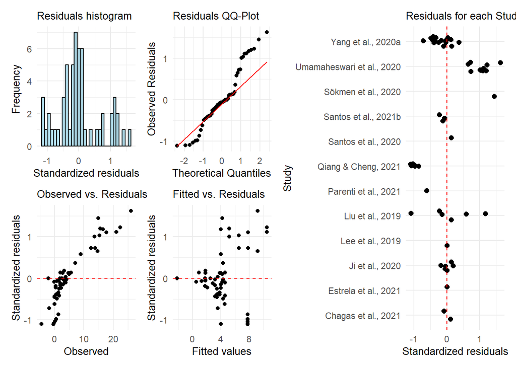

#### Influential cases

#### Orchard plots

# Referências

Harrer, Mathias, Pim Cuijpers, Toshi A. Furukawa, and David D. Ebert. n.d. *Chapter 9 Publication Bias | Doing Meta-Analysis in R*. https://bookdown.org/MathiasHarrer/Doing_Meta_Analysis_in_R/pub-bias.html.

Nakagawa, Shinichi, Malgorzata Lagisz, Michael D. Jennions, Julia Koricheva, Daniel W. A. Noble, Timothy H. Parker, Alfredo Sánchez-Tójar, Yefeng Yang, and Rose E. O’Dea. 2022. “Methods for Testing Publication Bias in Ecological and Evolutionary Meta-Analyses.” *Methods in Ecology and Evolution* 13 (1): 4–21. https://doi.org/10.1111/2041-210X.13724.

Nakagawa, Shinichi, Malgorzata Lagisz, Rose E. O’Dea, Joanna Rutkowska, Yefeng Yang, Daniel W. A. Noble, and Alistair M. Senior. 2021. “The Orchard Plot: Cultivating a Forest Plot for Use in Ecology, Evolution, and Beyond.” *Research Synthesis Methods* 12 (1): 4–12. https://doi.org/10.1002/jrsm.1424.

Stanley, T. D. 2017. “Limitations of PET-PEESE and Other Meta-Analysis Methods.” *Social Psychological and Personality Science* 8 (5): 581–91. https://doi.org/10.1177/1948550617693062.

Viechtbauer, Wolfgang. 2010. “Conducting Meta-Analyses in R with the Metafor Package.” *Journal of Statistical Software* 36 (August): 1–48. https://doi.org/10.18637/jss.v036.i03.

———. 2022. “Konstantopoulos (2011) [the Metafor Package].” https://www.metafor-project.org/doku.php/analyses:konstantopoulos2011.

Viechtbauer, Wolfgang, and Mike W.-L. Cheung. 2010. “Outlier and Influence Diagnostics for Meta-Analysis.” *Research Synthesis Methods* 1 (2): 112–25. https://doi.org/10.1002/jrsm.11.

Yang, Yefeng, Malcolm Macleod, Jinming Pan, Malgorzata Lagisz, and Shinichi Nakagawa. 2023. “Advanced Methods and Implementations for the Meta-Analyses of Animal Models: Current Practices and Future Recommendations.” *Neuroscience & Biobehavioral Reviews* 146 (March): 105016. https://doi.org/10.1016/j.neubiorev.2022.105016.